# Coursework Report

*N* removed NAs: 3

*N* removed typo: 1

*N* removed <18: 17

*N* total clean: 129

| Group | *N* | *M*<sub>age</sub> | *M*<sub>rating</sub> |
| --- | --- | --- | --- |
| Control | 58 | 21.09 | 5.74 |
| Experim | 71 | 21.41 | 7.15 |

**Main analysis results**

*t*(127) = -10.84, *p* < .001

[interactive chart not shown]

[figure not shown]

[interactive chart not shown]

# Coursework Report

Analysing Data, Spring 2020

# Methods

## Participants

Of these 129 participants, the age range was 18 to 29. The participants’ mean age was 21.26 and they had a standard deviation of 2.17.

Table 1 *Participant Descriptives by Age*

| *Mean*<sub>age</sub> | *SD*<sub>age</sub> | *Min*<sub>age</sub> | *Max*<sub>age</sub> |
| --- | --- | --- | --- |
| 21.26 | 2.17 | 18 | 29 |

Table 2 *Participant Descriptives by Experimental Condition and Age*

| Condition | *N* | % | *Mean*<sub>age</sub> | *SD*<sub>age</sub> |
| --- | --- | --- | --- | --- |
| control | 58 | 44.96 | 21.09 | 2.0 |
| experimental | 71 | 55.04 | 21.41 | 2.3 |

## Design

In this study, we completed a replication of Elliot et al.,’s (2010) study to see whether colour, specifically the colour red, makes a man appear more attractive to women and to see whether the red effect is replicable.

There were two conditions which were the control and experimental conditions and these were factors in the experiment. In the control condition, participants were shown a black and white image of a male on a white background for five seconds, and in the experimental condition, participants were shown a black and white image of a male on a red background for five seconds.

Particpants were then asked to rate how attractive they found each male. Attractiveness was measured by asking participants three questions:

1. “How attractive do you think this person is?”
2. “How pleasant is this person to look at?”
3. “If I were to meet this person in this picture face to face, I would think he is attractive.”

All three questions were rated on a 9-point-scale. 1 being not attractive at all, and 9 being extremely attractive. The results from all three questions were combined to form an average composite score.

As a result, it was hypothesised that women would rate men with a red background higher on a 9-point-scale of attractiveness than men with a white background. To test this hypothesis we used a *t* test.

# Results

Overall, the results from the study show that participants, on average, gave a higher attractiveness rating if they were in the experimental condition. This is true for all three questions that partipants were asked.

Below shows a table for each question broken down by condition:

Table 3 *Mean Attractiveness Score for each Question by Condition*

| Condition | *N* | *M*<sub>Question_1</sub> | *M*<sub>Question_2</sub> | *M*<sub>Question_3</sub> |
| --- | --- | --- | --- | --- |
| control | 58 | 5.86 | 5.84 | 5.50 |
| experimental | 71 | 6.97 | 7.31 | 7.17 |

We investigated whether participants would give different attractiveness ratings depending on whether the image was on a white background or a red background, using an independent measures *t*-test.

The analysis showed that participants in the experimental condition (red background) gave a higher mean attractiveness rating (*M* = 7.15) than participants in the control condition who saw an image with a white background (*M* = 5.74).

We also created a means plot graph which shows this difference in mean scores for the control and experimental conditions. In order to do this, we calculated a composite score. This is where we added up each person’s scores from all three questions and calculated their mean score. We then plotted this on a graph showing the difference in mean scores between the control and experimental condition.

Below is a mean plot graph that shows the difference in means of the two conditions:

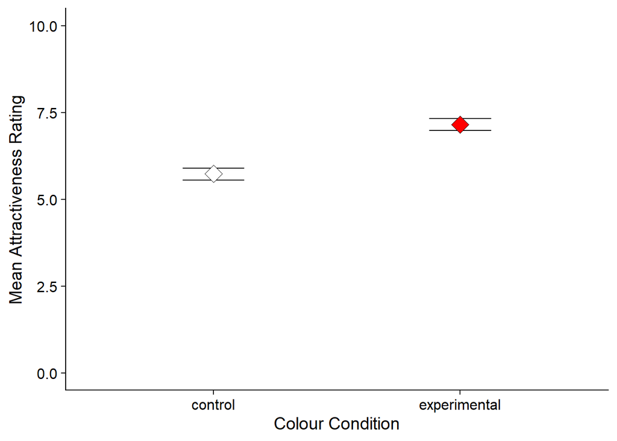

# Discussion

The results from the study show that participants in the experimental condition, who viewed an image on a red background, gave higher attractiveness ratings than participants in the control condition, who viewed an image on a white background. This supports our research question that the colour red makes men appear more attractive to women and it also supports the idea that the red effect is replicable.

The results obtained in my study are similar to that of Elliot et al., (2010) study. Both of our studies found that participants in the experimental condition gave a higher mean attractiveness score than those in the control condition. They also both found a significant effect in the results, which suggests that the colour red does influence participants’ attractiveness ratings.

Although, many people have also replicated Elliot et al., (2010) study, and found different results for the red effect. In a study conducted by Peperkoorn, Roberts and Pollet (2016) they conducted multiple replications in order to investigate the red effect in which men rated women’s attractiveness by looking at women wearing either a red or white shirt, but found that the colour red didn’t have a significant effect on attractiveness ratings - this was true when participants were looking for both a short or long-term mating partner. Similarly, Hesslinger, Goldbach and Carbon (2015) conducted a replication of Elliot et al’s (2010) study and didn’t find a statistically significant effect of the colour red increasing attractiveness ratings. Although, what they did find was that apparel style had a significant effect - men wearing a formal outfit were perceived as more attractive than men wearing a casual outfit. As well as this, a meta-analysis of nine replications were carried out and it was found that the red effect couldn’t be replicated and the colour red didn’t have a significant effect in any of these studies (Wagge et al., 2019). These studies therefore suggest that the red effect may not be as real as first thought and questions the ecological validity of the procedure of Elliot et al (2010) study and my replication.

A strength of the research is the high control of extraneous variables. We made sure that the only variable being manipulated was the background colour. This means that because of this we can conclude the attractivness ratings were due to the colour of the background rather than other factors and so this suggests that the red-attractiveness effect is significant. As well as this, other studies have also found similar findings to mine. For example, one study found that men rating women’s attractiveness on meeting sites online, rated the woman as more sexually attractive when wearing a red top in comparison to other coloured tops such as white, green or blue (Gueguen & Jacob, 2013). This therfore supports our findings that the colour red can increase perceived attractivenss ratings.

Although, a limitation of the study is that the image was presented to participants for only five seconds, after which they could no longer view it. This could be a problem as this may not be enough time for some participants to properly view the image and so their attractiveness ratings may not be accurate. As a result the red effect may be limited due to the viewing time.

Furthermore, another limitation of the study is that the same picture was shown to each participant. However, individual differences between participants could affect the attractiveness ratings that they give. For example, they will find different men attractive, and have a different ‘type’. This means that the attractiness ratings that participants give could be due to this, rather than due to the colour of the background. As a result the findings may reflect idiosyncrasies between individuals, rather than the red-attractiveness effect.

With the contradicting evidence on this topic, I think that this research question should be investigated further to see whether the red-attractiveness effect is a true effect and it’s not due to publication bias which many people have criticised Elliot et al., (2010) for (Francis, 2010). In terms of future studies, to test this further, a larger sample of photos could be used where participants rate the attractiveness of a diverse range of participants who vary in their features. For example, Peperkoorn et al., (2016) used images where women had a darker skin tone compared to the other experiments. This should help to control for individual differences between participants.

As well as this, future studies may want to investigate the red-attractiveness effect in a more real-life setting to improve the ecological validity. For example, Gueguen and Jacob (2012) conducted a study where they investigated the red-attractiveness effect on waiters/ waitresses’ tips. They found that men tipped women waitresses more if they were wearing a red top as they found them more attractive, but no effect was found for women when tipping the waiters. Similarly, Gueguen and Jacob (2013) conducted a study on a more up-to-date way of dating where the red effect was investigated using online meeting sites. This should improve the study and should help to show us whether the red-attractiveness happens in real, everyday life or whether it is the result of a controlled, artificial setting.

In conclusion, the study obtained significant results showing that the colour red does influence attractiveness ratings, which supports our initial research question. However, many replications have also been conducted and haven’t found a significant effect, which questions whether the effect is true or not. Due to this, future studies should be conducted that avoid the limitations of the study and improve the ecological validity in order to investigate this research question further.

# References

Elliot, A. J., Niesta Kayser, D., Greitemeyer, T., Lichtenfeld, S., Gramzow, R. H., Maier, M. A., & Liu, H. (2010). Red, rank, and romance in women viewing men. *Journal of Experimental Psychology: General, 139*(3), 399.

Peperkoorn, L. s., Roberts, S. C., & Pollet, T. V. (2016). Revisiting the Red Effect on Attractiveness and Sexual Receptivity: No Effect of the Color Red on Human Mate Preferences . *Evolutionary Psychology, 13*(1), 1- 13.

Hesslinger, V. M., Goldbach, L., & Carbon, C. C. (2015). Men in red: A reexamination of the red-attractiveness effect. *Psychonomic society, 22*, 1142 - 1148.

Wagge, J. R., Baciu, C., Banas, K., Nadler, J. T., Schwarz, S., Weisberg, Y., IJzerman, H., Legate, N & Grahe, J. (2019). A Demonstration of the Collaborative Replication and Education Project: Replication Attempts of the Red-Romance Effect. *Collabra Psychology, 5* (1), 2 - 9.

Gueguen, N., & Jacob, C. (2013). Color and Cyber-Attractiveness: Red Enhances Men’s Attraction to Women’s Internet Personal Ads. *Research and application, 38*(4), 309-312.

Francis, G. (2013).Publication Bias in “Red, Rank, and Romance in Women Viewing Men,” by Elliot et al. *Journal of Experimental Psychology: General, 142*(1), 292-296.

Gueguen, N., & Jacob, C (2012). Clothing Color and Tipping: Gentlemen Patrons Give More Tips to Waitresses with Red Clothes . *Journal of hospitality & Tourism research, 38*(2), 275- 280.